# Exploratory Data Analysis of the SwiftKey Corpus

Michael Nichols

May 11, 2018

### *Data Science Specialization Capstone Project*

### Tasks to accomplish

1. Exploratory analysis - perform a thorough exploratory analysis of the data, understanding the distribution of words and relationship between the words in the corpora.
2. Understand frequencies of words and word pairs - build figures and tables to understand variation in the frequencies of words and word pairs in the data.

### Initial Exploratory Analysis

### *Descriptive Statistics: Blogs, News, Twitter*

| file | Totals totalLines | Totals totalWords | Totals totalChars | Words by Entry averageWords | Words by Entry minWords | Words by Entry maxWords | Characters by Entry averageChars | Characters by Entry minChars | Characters by Entry maxChars |
| --- | --- | --- | --- | --- | --- | --- | --- | --- | --- |
| blogs | 44965 | 1454377 | 9425914 | 32.34 | 1 | 1030 | 209.63 | 5 | 7293 |
| news | 3863 | 105488 | 719493 | 27.31 | 1 | 196 | 186.25 | 9 | 1220 |
| twitter | 118008 | 1277890 | 7954230 | 10.83 | 1 | 43 | 67.40 | 6 | 149 |

Creating a tokenized version of each dataset:

```r
#tokenize the data frames (split each word from each document into its own row)
#also remove 'stopwords': extremely common words not valuable for an analysis (e.g. as, of, the , a, ..., etc.)
tokenized_blogs <- clean_blogs_df %>%
        unnest_tokens(output = word, input = text) %>%
        anti_join(get_stopwords())

tokenized_news <- clean_news_df %>%
        unnest_tokens(output = word, input = text) %>%
        anti_join(get_stopwords())

tokenized_twitter <- clean_twitter_df %>%
        unnest_tokens(output = word, input = text) %>%
        anti_join(get_stopwords())
```

### Further Exploratory Visualizations

*Based off a randomly sampled 5% of the full datasets*

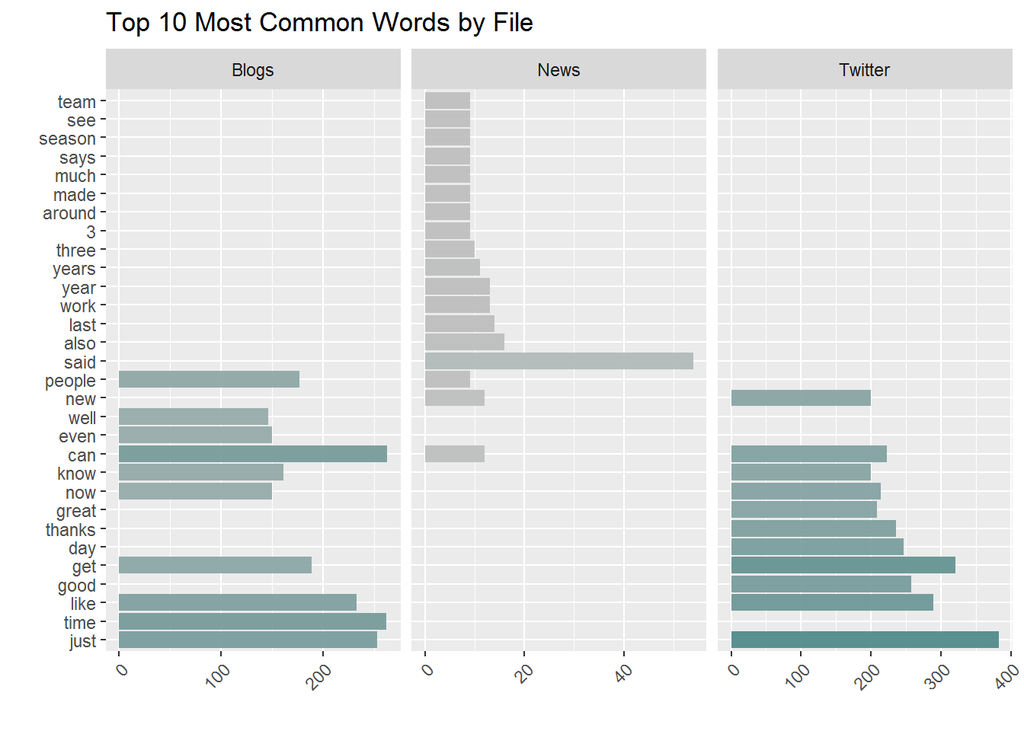

### N-gram Analysis

Per file, the following code gathers the top 10 most common 2-word (bigram) and 3-word (trigram) strings. This code ignore stop words (e.g. as, of, the , a, …, etc.) to show drive more substantial insights.

*Based off a randomly sampled 5% of the full datasets*

```r
#n-gram analysis
#bigrams
bigram_Analysis <- function(text, filetype) {
        text %>%
                unnest_tokens(bigram, text, token = "ngrams", n = 2) %>%
                tidyr::separate(bigram, c("word1", "word2"), sep = " ") %>%
                na.omit() %>%
                filter(!word1 %in% stop_words$word,
                       !word2 %in% stop_words$word) %>%
                count(word1, word2, sort = TRUE) %>%
                top_n(n = 10, wt = n) %>% #selects only top 10 values
                slice(row_number(1:10)) %>% #prevents ties (i.e. several bigrams with the 10th highest value)
                mutate(bigram = paste(word1, word2, sep = " ")) %>%
                mutate(file = filetype)
}

blogs_bigram <- bigram_Analysis(clean_blogs_df, "Blogs")
news_bigram <- bigram_Analysis(clean_news_df, "News")
twitter_bigram <- bigram_Analysis(clean_twitter_df, "Twitter")

#combine for easy visualizations
bigram_all <- as.data.frame(rbind.data.frame(blogs_bigram, news_bigram, twitter_bigram))

#trigrams
trigram_Analysis <- function(text, filetype) {
        text %>%
                unnest_tokens(trigram, text, token = "ngrams", n = 3) %>%
                tidyr::separate(trigram, c("word1", "word2", "word3"), sep = " ") %>%
                na.omit() %>%
                filter(!word1 %in% stop_words$word,
                       !word2 %in% stop_words$word,
                       !word3 %in% stop_words$word) %>%
                count(word1, word2, word3, sort = TRUE) %>%
                top_n(n = 10, wt = n) %>%
                slice(row_number(1:10)) %>%
                mutate(trigram = paste(word1, word2, word3, sep = " ")) %>%
                mutate(file = filetype)
}

blogs_trigram <- trigram_Analysis(clean_blogs_df, "Blogs")
news_trigram <- trigram_Analysis(clean_news_df, "News")
twitter_trigram <- trigram_Analysis(clean_twitter_df, "Twitter")

#combine for easy visualizations
trigram_all <- as.data.frame(rbind.data.frame(blogs_trigram, news_trigram, twitter_trigram))
```

### *Visualize the Bigrams & Trigrams*

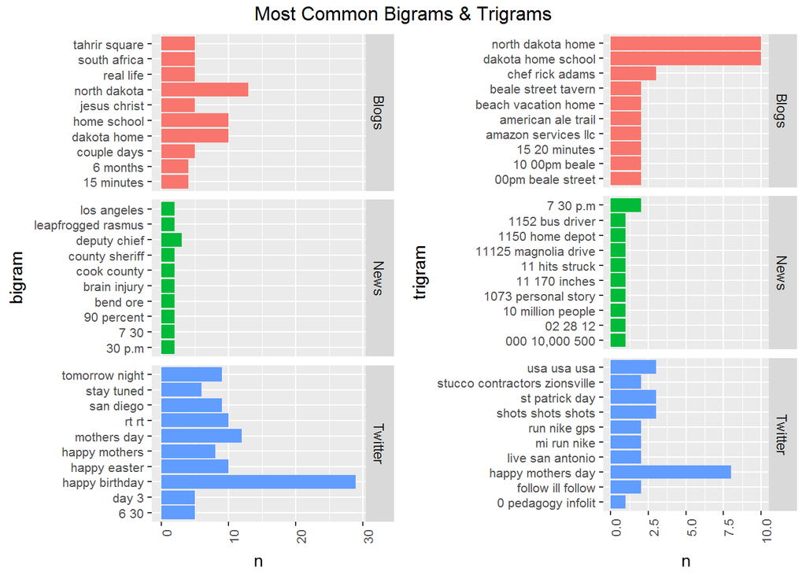

### *Plot of concentration of certain words (only shows terms that make up .50 of the total)*

Plots with higher bars on the left have more unique terms (more instances where the frequency of a certain word is very small).

*Below the plot is a table displaying the number of unique words required to hit the specified percentages of all words in the text*

Hypothetical example to illustrate this concept: The word ‘the’ could occur 200 times in a 10,000 word document, thus consisting of 2% of all words in a document.

*Based off a randomly sampled 5% of the full datasets*

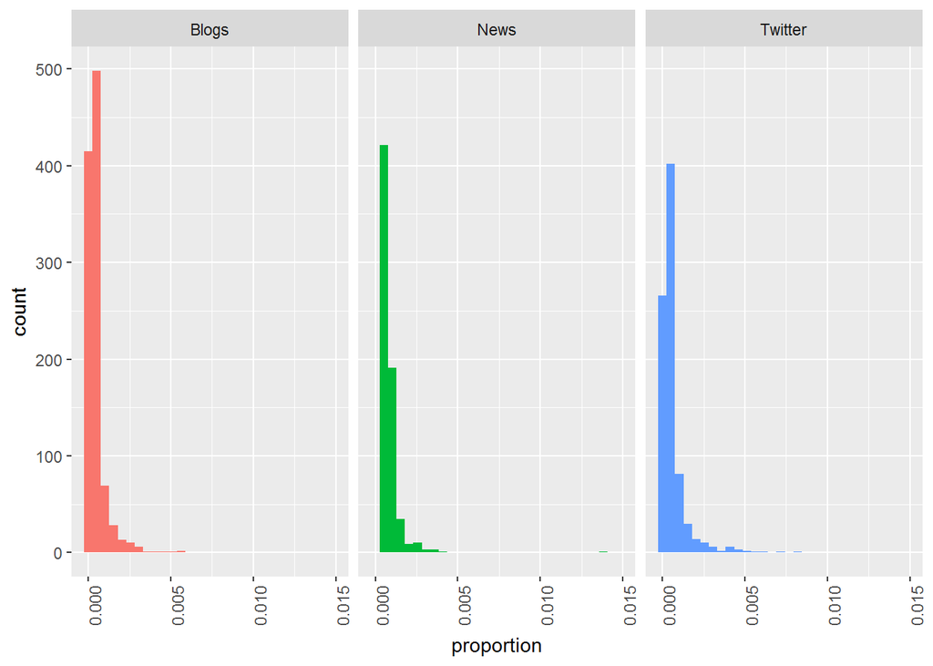

| file | Unique Terms to Cover X Percent of Total Words 0.1 | Unique Terms to Cover X Percent of Total Words 0.3 | Unique Terms to Cover X Percent of Total Words 0.5 | Unique Terms to Cover X Percent of Total Words 0.7 | Unique Terms to Cover X Percent of Total Words 0.9 | Unique Terms to Cover X Percent of Total Words 1 |
| --- | --- | --- | --- | --- | --- | --- |
| Blogs | 38 | 302 | 1076 | 3220 | 10314 | 14945 |
| News | 43 | 269 | 693 | 1462 | 2230 | 2596 |
| Twitter | 24 | 191 | 855 | 3501 | 12158 | 16571 |

## Questions to Consider

*1. How can you efficiently store an n-gram model (think Markov Chains)?*

Store the original corpus in n-gram tokenized data tables. Using the n-gram models, bits are dependent on the frequency of its occurrence after some other word(s). By using the Markov Assumption, we can simplify our process by assuming that future states in our model only depend upon the present state of our model. This assumption means that we can reduce our conditional probabilities to be approximately equal so that

P(‘rain’|‘There was heavy’) ~ P(‘rain’|‘heavy’)

More generally, we can estimate the probability of a sentence by the probabilities of each component part. In the equation that follows, the probability of the sentence is reduced to the probabilities of the sentence’s individual bigrams.

P(‘There was heavy rain’) ~ P(‘There’)P(‘was’|‘There’)P(‘heavy’|‘was’)P(‘rain’|‘heavy’)

*2. How can you use the knowledge about word frequencies to make your model smaller and more efficient?*

*3. How many parameters do you need (i.e. how big is n in your n-gram model)?*

Tri-grams, at least for the initial model, will be the largest parameter.

*4. Can you think of simple ways to “smooth” the probabilities (think about giving all n-grams a non-zero probability even if they aren’t observed in the data)?*

Additive (Laplace) smoothing: add 1 to all counts to avoid zero frequencies (Laplace Smoothing)

*5. How do you evaluate whether your model is any good?* Perplexity: measurement of how well a probability distribution or probability model predicts a sample. It may be used to compare probability models. A low perplexity indicates the probability distribution is good at predicting the sample.

*6. How can you use backoff models to estimate the probability of unobserved n-grams?*

Discounting: we can select an absolute discount which artificially lowers the counts of observed n-grams and distributes this “stolen” probabilty mass to unobserved n-grams.

### *Wordclouds*

Now looking at all the files together without first filtering for the most common words, create 3 wordcloud: individual word, bigrams, and trigrams. – This visualization could be well suited for a final data product (Shiny app).

*Based of a randomly sampled 5% of the full datasets*

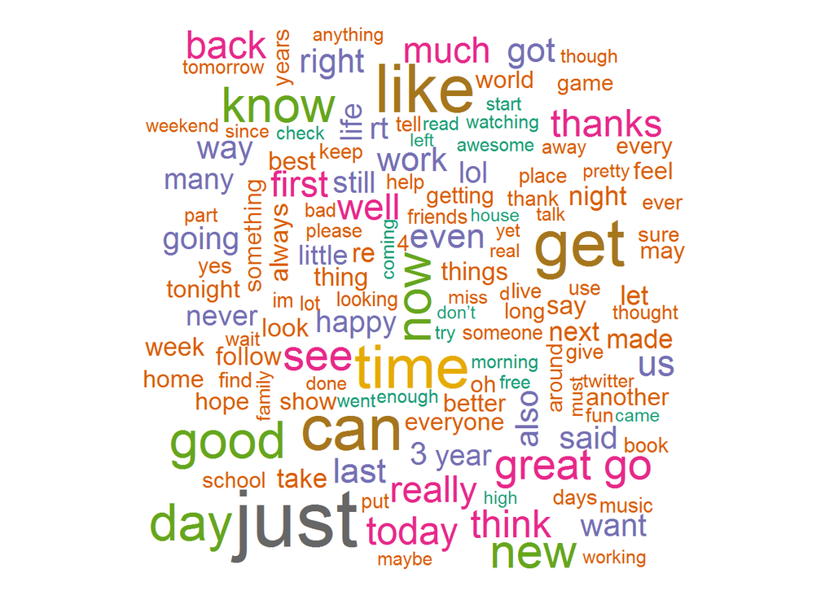

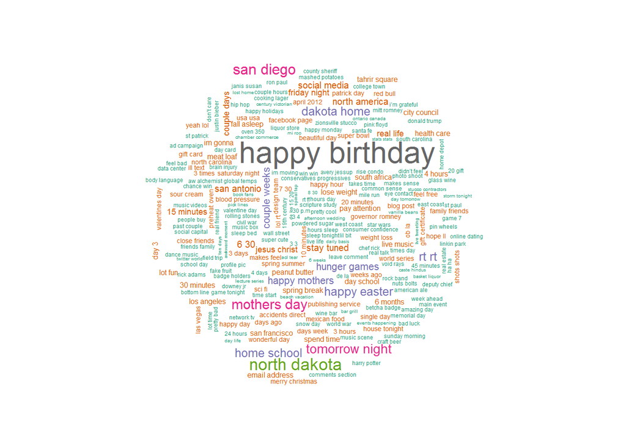

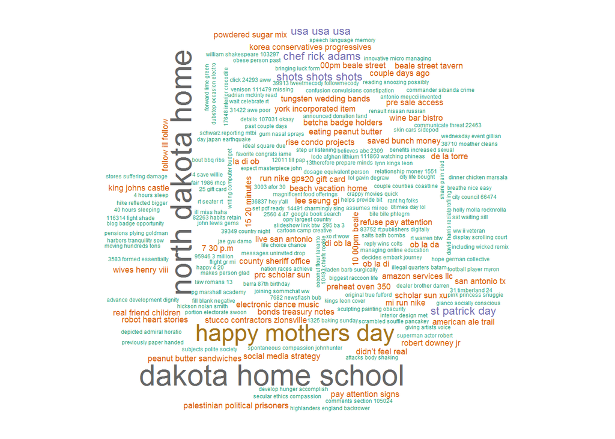